# R Notebook

1 MVP You have been provided with a set of data on customer purchases of either ‘Citrus Hill’ (purchase = ‘CH’) or ‘Minute Maid’ (purchase = ‘MM’) orange juice, together with some further attributes of both the customer and the store of purchase. A data dictionary is also provided in the data directory.

We would like you to build the best predictive classifier you can of whether a customer is likely to buy Citrus Hill or Minute Maid juice. Use logistic regression to do this. You should use either train-test splitting or cross-validation to evaluate your classifier. The metric for ‘best classifier’ will be highest AUC value either in the test set (for train-test splitting) or from cross-validation.

Issues we faced, thoughts we had

This is quite a tough, open-ended exercise. We decided early on to use an automated approach to model selection using glmulti(), but feel free to use a manual approach if you prefer! The Purchase dependent variable will require wrangling to work in logistic regression. We replaced it with a purchase_mm logical variable. Wrangle other categorical variables to be factors too. WeekOfPurchase is also quite tough to deal with: should it be added as a factor variable (it will lead to many coefficients), left as numeric, or omitted entirely? See if you can come up with a strategy to decide what to do with it. Check for aliased variables and remove any aliases before you set off to find your best models. Remember, you can use something like alias(purchase_mm ~ ., data = oj) to do this, the dot . here means ‘all variables’. Aliased variables will be listed down the left-hand side, and you can subsequently remove them.

glmulti() hints

If you decide to use glmulti() be prepared for your R session to hang if you decide to abort a run! The reason for this is that glmulti() actually uses a separate Java runtime to do its thing in the background, and unfortunately R can’t instruct Java to terminate on request. D’oh! Accordingly, make sure you save any changes to your work before each glmulti() run. That way, you can force quit RStudio if necessary without losing work.

```r
library(pROC)
```

```r
# check there is no NA - OK!
orange_juice %>%
  summarise(across(.fns = ~ sum(is.na(.x))))
```

| purchase | weekof_purchase | store_id | price_ch | price_mm | disc_ch | disc_mm | special_ch | special_mm | loyal_ch | sale_price_mm | sale_price_ch | price_diff | store7 | pct_disc_mm | pct_disc_ch | list_price_diff | store |
| --- | --- | --- | --- | --- | --- | --- | --- | --- | --- | --- | --- | --- | --- | --- | --- | --- | --- |
| 0 | 0 | 0 | 0 | 0 | 0 | 0 | 0 | 0 | 0 | 0 | 0 | 0 | 0 | 0 | 0 | 0 | 0 |

```r
# tidy data for logistic regression
# store, store_id and store 7 carry the same information, I keep just store_id
# change character variables to factor
orange_juice <- orange_juice %>%
  mutate(
    purchase_mm = ifelse(purchase == "MM", 1, 0) %>% as.factor(),
    weekof_purchase = as.factor(weekof_purchase),
    store_id = as.factor(store_id),
    special_ch = as.factor(special_ch),
    special_mm = as.factor(special_mm)
  ) %>%
  select(-c(weekof_purchase, store, store7, purchase))

glimpse(orange_juice)
```

```
Rows: 1,070
Columns: 15
$ store_id        <fct> 1, 1, 1, 1, 7, 7, 7, 7, 7, 7, 7, 7, 7, 7, 7, 7, 1, 2, 2, 7, 7, 1, 7, 7, 7, 7, 7, 7, 7, 7, 2, 7,…
$ price_ch        <dbl> 1.75, 1.75, 1.86, 1.69, 1.69, 1.69, 1.69, 1.75, 1.75, 1.75, 1.86, 1.86, 1.99, 1.86, 2.06, 2.06,…
$ price_mm        <dbl> 1.99, 1.99, 2.09, 1.69, 1.69, 1.99, 1.99, 1.99, 1.99, 1.99, 2.09, 2.13, 2.13, 2.13, 2.13, 2.13,…
$ disc_ch         <dbl> 0.00, 0.00, 0.17, 0.00, 0.00, 0.00, 0.00, 0.00, 0.00, 0.00, 0.00, 0.27, 0.00, 0.00, 0.00, 0.00,…
$ disc_mm         <dbl> 0.00, 0.30, 0.00, 0.00, 0.00, 0.00, 0.40, 0.40, 0.40, 0.40, 0.00, 0.00, 0.54, 0.00, 0.00, 0.00,…
$ special_ch      <fct> 0, 0, 0, 0, 0, 0, 1, 1, 0, 0, 0, 0, 0, 0, 0, 0, 0, 0, 0, 0, 0, 0, 0, 1, 0, 1, 0, 0, 1, 0, 0, 1,…
$ special_mm      <fct> 0, 1, 0, 0, 0, 1, 1, 0, 0, 0, 0, 0, 1, 0, 0, 0, 1, 1, 0, 0, 0, 0, 0, 0, 0, 0, 0, 0, 0, 0, 0, 0,…
$ loyal_ch        <dbl> 0.500000, 0.600000, 0.680000, 0.400000, 0.956535, 0.965228, 0.972182, 0.977746, 0.982197, 0.985…
$ sale_price_mm   <dbl> 1.99, 1.69, 2.09, 1.69, 1.69, 1.99, 1.59, 1.59, 1.59, 1.59, 2.09, 2.13, 1.59, 2.13, 2.13, 2.13,…
$ sale_price_ch   <dbl> 1.75, 1.75, 1.69, 1.69, 1.69, 1.69, 1.69, 1.75, 1.75, 1.75, 1.86, 1.59, 1.99, 1.86, 2.06, 2.06,…
$ price_diff      <dbl> 0.24, -0.06, 0.40, 0.00, 0.00, 0.30, -0.10, -0.16, -0.16, -0.16, 0.23, 0.54, -0.40, 0.27, 0.07,…
$ pct_disc_mm     <dbl> 0.000000, 0.150754, 0.000000, 0.000000, 0.000000, 0.000000, 0.201005, 0.201005, 0.201005, 0.201…
$ pct_disc_ch     <dbl> 0.000000, 0.000000, 0.091398, 0.000000, 0.000000, 0.000000, 0.000000, 0.000000, 0.000000, 0.000…
$ list_price_diff <dbl> 0.24, 0.24, 0.23, 0.00, 0.00, 0.30, 0.30, 0.24, 0.24, 0.24, 0.23, 0.27, 0.14, 0.27, 0.07, 0.07,…
$ purchase_mm     <fct> 0, 0, 0, 1, 0, 0, 0, 0, 0, 0, 0, 0, 0, 0, 0, 0, 1, 1, 1, 0, 0, 0, 0, 0, 0, 0, 0, 0, 0, 0, 0, 0,…
```

```r
# check for remaining aliases
alias(purchase_mm ~ ., data = orange_juice)
```

```
using type = "numeric" with a factor response will be ignored‘-’ not meaningful for factors
```

```
Model :
purchase_mm ~ store_id + price_ch + price_mm + disc_ch + disc_mm +
    special_ch + special_mm + loyal_ch + sale_price_mm + sale_price_ch +
    price_diff + pct_disc_mm + pct_disc_ch + list_price_diff

Complete :
                (Intercept) store_id2 store_id3 store_id4 store_id7 price_ch price_mm disc_ch disc_mm special_ch1
sale_price_mm    0           0         0         0         0         0        1        0      -1       0
sale_price_ch    0           0         0         0         0         1        0       -1       0       0
price_diff       0           0         0         0         0        -1        1        1      -1       0
list_price_diff  0           0         0         0         0        -1        1        0       0       0
                special_mm1 loyal_ch pct_disc_mm pct_disc_ch
sale_price_mm    0           0        0           0
sale_price_ch    0           0        0           0
price_diff       0           0        0           0
list_price_diff  0           0        0           0
```

```r
orange_juice <- orange_juice %>%
  select(-c(sale_price_mm, sale_price_ch, price_diff, list_price_diff))
```

```r
# train-test splitting. The createDataPartition() function has the nice feature that it takes in a y= argument specifying outcomes, and it will try to ensure similar distributions of those outcomes in train and test sets

set.seed(123)

train_index <- createDataPartition(orange_juice$purchase_mm, p = 0.8, list = FALSE, times = 1)

train <- orange_juice[train_index, ]
test <- orange_juice[-train_index, ]
```

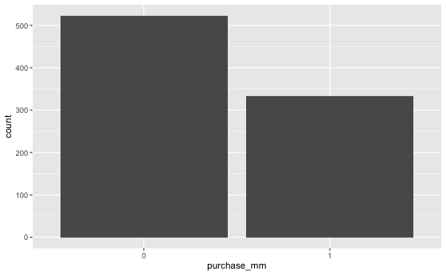

```r
# check the distribution of outcome (target) variable purchase_mm is similarly distributed in both train and test data sets - OK!
train %>%
  ggplot(aes(x = purchase_mm)) +
  geom_bar()
```

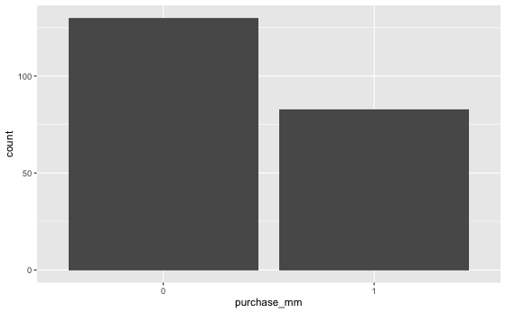

```r
test %>%
  ggplot(aes(x = purchase_mm)) +
  geom_bar()
```

### All-subset linear regression using glm() based on BIC

```r
# use glmulti() for predictor selection
glmulti_search_all_mains <- glmulti(
  purchase_mm ~ .,                   # model to fit, in this case, purchase_mm varies with everything (.)
  data = train,                      # data to use for fitting
  level = 1,                         # level = 2 means try pairwise interactions. level = 1 means main effects only
  method = "h",                      # method "d" means trial run, to get size of problem. Set to "h" for exhaustive search, or "g" for genetic algorithm
  crit = bic,                        # criterion for selecting best models.
  confsetsize = 10,                  # how many models should glmulti() return? keep 10 best models
  plotty = FALSE,                    # provide progress plots? Generally annoying.
  report = FALSE,                    # provide progress reports? Generally useful.
  fitfunction = "glm",               # use glm() as fit function (logistic regression). Use lm() for linear regression.
  family = binomial(link = "logit")) # binomial family for logistic regression

summary(glmulti_search_all_mains)
```

```
$name
[1] "glmulti.analysis"

$method
[1] "h"

$fitting
[1] "glm"

$crit
[1] "bic"

$level
[1] 1

$marginality
[1] FALSE

$confsetsize
[1] 10

$bestic
[1] 681.9811

$icvalues
 [1] 681.9811 681.9842 683.0634 683.0713 684.9326 685.0040 685.6692 685.7445 685.9482 686.2120

$bestmodel
[1] "purchase_mm ~ 1 + price_ch + price_mm + disc_mm + loyal_ch + "
[2] "    pct_disc_ch"

$modelweights
 [1] 0.23934110 0.23896301 0.13931563 0.13876618 0.05471523 0.05279516 0.03785805 0.03645868 0.03292741 0.02885954

$includeobjects
[1] TRUE
```

```r
# show 10 best models
glmulti_search_all_mains@formulas
```

```
[[1]]
purchase_mm ~ 1 + price_ch + price_mm + disc_mm + loyal_ch +
    pct_disc_ch
<environment: 0x7ffc4bd6b2a8>

[[2]]
purchase_mm ~ 1 + price_ch + price_mm + disc_ch + disc_mm + loyal_ch
<environment: 0x7ffc4bd6b2a8>

[[3]]
purchase_mm ~ 1 + price_ch + price_mm + disc_ch + loyal_ch +
    pct_disc_mm
<environment: 0x7ffc4bd6b2a8>

[[4]]
purchase_mm ~ 1 + price_ch + price_mm + loyal_ch + pct_disc_mm +
    pct_disc_ch
<environment: 0x7ffc4bd6b2a8>

[[5]]
purchase_mm ~ 1 + price_ch + price_mm + disc_mm + loyal_ch +
    pct_disc_mm + pct_disc_ch
<environment: 0x7ffc4bd6b2a8>

[[6]]
purchase_mm ~ 1 + price_ch + price_mm + disc_ch + disc_mm + loyal_ch +
    pct_disc_mm
<environment: 0x7ffc4bd6b2a8>

[[7]]
purchase_mm ~ 1 + disc_mm + loyal_ch + pct_disc_ch
<environment: 0x7ffc4bd6b2a8>

[[8]]
purchase_mm ~ 1 + price_mm + disc_mm + loyal_ch + pct_disc_ch
<environment: 0x7ffc4bd6b2a8>

[[9]]
purchase_mm ~ 1 + disc_ch + disc_mm + loyal_ch
<environment: 0x7ffc4bd6b2a8>

[[10]]
purchase_mm ~ 1 + price_mm + disc_ch + disc_mm + loyal_ch
<environment: 0x7ffc4bd6b2a8>
```

```r
## show result for the best model
summary(glmulti_search_all_mains@objects[[1]])
```

```
Call:
fitfunc(formula = as.formula(x), family = ..1, data = data)

Deviance Residuals:
    Min       1Q   Median       3Q      Max
-2.8779  -0.5468  -0.2206   0.4884   2.8850

Coefficients:
            Estimate Std. Error z value Pr(>|z|)
(Intercept)   2.9060     1.7947   1.619  0.10541
price_ch      4.2269     1.3150   3.214  0.00131 **
price_mm     -3.7217     0.9239  -4.028 5.61e-05 ***
disc_mm       2.6257     0.4774   5.500 3.81e-08 ***
loyal_ch     -6.9157     0.4691 -14.743  < 2e-16 ***
pct_disc_ch  -8.1108     1.8475  -4.390 1.13e-05 ***
---
Signif. codes:  0 ‘***’ 0.001 ‘**’ 0.01 ‘*’ 0.05 ‘.’ 0.1 ‘ ’ 1

(Dispersion parameter for binomial family taken to be 1)

    Null deviance: 1146.03  on 856  degrees of freedom
Residual deviance:  641.46  on 851  degrees of freedom
AIC: 653.46

Number of Fisher Scoring iterations: 5
```

### found the best model using main effect only (lowest BIC):

```r
# add pairwise interactions to the best main effect model
glmulti_search_previous_mains_one_pair <- glmulti(
  purchase_mm ~ 1 + price_ch + price_mm + disc_mm + loyal_ch + pct_disc_mm + pct_disc_ch,
  data = train,                      # data to use for fitting
  level = 2,                         # level = 2 means try pairwise interactions. level = 1 means main effects only
  method = "h",                      # method "d" means trial run, to get size of problem. Set to "h" for exhaustive search, or "g" for genetic algorithm
  crit = bic,                        # criterion for selecting best models.
  confsetsize = 10,                  # how many models should glmulti() return? keep 10 best models
  marginality = TRUE,                # marginality true means include pairwise interaction only if both main effects present in model
  minsize = 6,                       # minsize, maxsize and marginality here force
  maxsize = 6,                       # inclusion of a single pair beyond the five main effects
  plotty = FALSE,
  report = TRUE,                     # no plots, but provide interim reports
  fitfunction = "glm",               # glm function
  family = binomial(link = "logit")) # binomial family for logistic regression
```

```
Initialization...
TASK: Exhaustive screening of candidate set.
Fitting...

After 50 models:
Best model: purchase_mm~1+price_ch+price_mm+loyal_ch+pct_disc_mm+price_mm:price_ch+pct_disc_mm:price_mm
Crit= 707.996735495422
Mean crit= 708.275762308942

After 100 models:
Best model: purchase_mm~1+price_ch+price_mm+disc_mm+loyal_ch+pct_disc_mm+pct_disc_mm:price_mm
Crit= 707.069801490796
Mean crit= 707.874236136132

After 150 models:
Best model: purchase_mm~1+price_ch+disc_mm+loyal_ch+pct_disc_ch+disc_mm:price_ch+pct_disc_ch:disc_mm
Crit= 699.03040312783
Mean crit= 701.420034463744

After 200 models:
Best model: purchase_mm~1+price_ch+price_mm+disc_mm+loyal_ch+pct_disc_ch+disc_mm:price_mm
Crit= 685.336848938617
Mean crit= 687.869324256731

After 250 models:
Best model: purchase_mm~1+price_ch+price_mm+disc_mm+loyal_ch+pct_disc_ch+disc_mm:price_mm
Crit= 685.336848938617
Mean crit= 687.869324256731

After 300 models:
Best model: purchase_mm~1+price_ch+price_mm+loyal_ch+pct_disc_mm+pct_disc_ch+pct_disc_mm:price_mm
Crit= 684.932421432181
Mean crit= 687.351932853722
Completed.
```

```r
summary(glmulti_search_previous_mains_one_pair)
```

```
$name
[1] "glmulti.analysis"

$method
[1] "h"

$fitting
[1] "glm"

$crit
[1] "bic"

$level
[1] 2

$marginality
[1] TRUE

$confsetsize
[1] 10

$bestic
[1] 684.9324

$icvalues
 [1] 684.9324 684.9326 685.3368 686.9654 687.2516 687.6848 688.0405 688.1932 688.1983 688.4300

$bestmodel
[1] "purchase_mm ~ 1 + price_ch + price_mm + loyal_ch + pct_disc_mm + "
[2] "    pct_disc_ch + pct_disc_mm:price_mm"

$modelweights
 [1] 0.22116768 0.22115294 0.18067637 0.08003293 0.06936129 0.05585486 0.04675246 0.04331535 0.04320652 0.03847959

$includeobjects
[1] TRUE
```

```r
glmulti_search_previous_mains_one_pair@formulas
```

```
[[1]]
purchase_mm ~ 1 + price_ch + price_mm + loyal_ch + pct_disc_mm +
    pct_disc_ch + pct_disc_mm:price_mm
<environment: 0x7ffc4e8673c0>

[[2]]
purchase_mm ~ 1 + price_ch + price_mm + disc_mm + loyal_ch +
    pct_disc_mm + pct_disc_ch
<environment: 0x7ffc4e8673c0>

[[3]]
purchase_mm ~ 1 + price_ch + price_mm + disc_mm + loyal_ch +
    pct_disc_ch + disc_mm:price_mm
<environment: 0x7ffc4e8673c0>

[[4]]
purchase_mm ~ 1 + price_ch + price_mm + disc_mm + loyal_ch +
    pct_disc_ch + pct_disc_ch:loyal_ch
<environment: 0x7ffc4e8673c0>

[[5]]
purchase_mm ~ 1 + price_ch + price_mm + disc_mm + loyal_ch +
    pct_disc_ch + pct_disc_ch:disc_mm
<environment: 0x7ffc4e8673c0>

[[6]]
purchase_mm ~ 1 + price_ch + price_mm + disc_mm + loyal_ch +
    pct_disc_ch + disc_mm:price_ch
<environment: 0x7ffc4e8673c0>

[[7]]
purchase_mm ~ 1 + price_ch + price_mm + loyal_ch + pct_disc_mm +
    pct_disc_ch + pct_disc_ch:loyal_ch
<environment: 0x7ffc4e8673c0>

[[8]]
purchase_mm ~ 1 + price_ch + price_mm + disc_mm + loyal_ch +
    pct_disc_ch + pct_disc_ch:price_mm
<environment: 0x7ffc4e8673c0>

[[9]]
purchase_mm ~ 1 + price_ch + price_mm + loyal_ch + pct_disc_mm +
    pct_disc_ch + pct_disc_mm:price_ch
<environment: 0x7ffc4e8673c0>

[[10]]
purchase_mm ~ 1 + price_ch + price_mm + loyal_ch + pct_disc_mm +
    pct_disc_ch + pct_disc_ch:pct_disc_mm
<environment: 0x7ffc4e8673c0>
```

```r
## show result for the best model containing pairwise interaction
glmulti_search_previous_mains_one_pair@objects[[1]]
```

```
Call:  fitfunc(formula = as.formula(x), family = ..1, data = data)

Coefficients:
         (Intercept)              price_ch              price_mm              loyal_ch           pct_disc_mm
               4.578                 3.851                -4.164                -6.963               -40.469
         pct_disc_ch  price_mm:pct_disc_mm
              -8.258                21.940

Degrees of Freedom: 856 Total (i.e. Null);  850 Residual
Null Deviance:      1146
Residual Deviance: 637.7    AIC: 651.7
```

### found the best model using main effect only (AIC: 653.46), added one pairwise interaction and found the new best model with the lowest BIC (AIC: 651.7):

*purchase_mm ~ 1 + price_ch + price_mm + loyal_ch + pct_disc_mm + pct_disc_ch + pct_disc_mm:price_mm*

Let’s use each of these 10 saved model objects (remember they have been trained on the train set) to predict `purchase_mm` for the *test* set and then calculate RMSE for each model on the test set

Note. RMSE - root-mean-square error measure of the differences between values (sample or population values) predicted by a model or an estimator and the values observed a lower RMSD is better than a higher one

```r
rmse_results <- numeric(10)
for (i in 1:10){
  this_model <- glmulti_search_previous_mains_one_pair@objects[[i]]
  predictions <- predict(this_model, newdata = test)
  rmse_results[i] <- sqrt(mean((predictions - as.numeric(test$purchase_mm))^2)) # need to change factor to numeric data type to allow calculations
}

rmse_results
```

```
 [1] 3.016577 3.016576 3.014258 3.175329 2.980169 2.997818 3.170068 3.004905 2.994281 2.973292
```

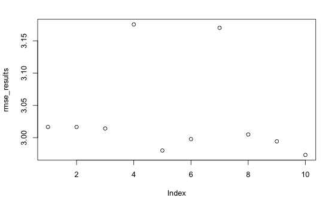

```r
# plot the RMSE for each model on test data set
plot(rmse_results)
```

```r
## show the model with lowest RMSE
glmulti_search_previous_mains_one_pair@formulas[[10]]
```

```
purchase_mm ~ 1 + price_ch + price_mm + loyal_ch + pct_disc_mm +
    pct_disc_ch + pct_disc_ch:pct_disc_mm
<environment: 0x7ffc4e8673c0>
```

```r
glmulti_search_previous_mains_one_pair@objects[[10]]
```

```
Call:  fitfunc(formula = as.formula(x), family = ..1, data = data)

Coefficients:
            (Intercept)                 price_ch                 price_mm                 loyal_ch
                  2.748                    4.136                   -3.580                   -6.912
            pct_disc_mm              pct_disc_ch  pct_disc_mm:pct_disc_ch
                  5.831                   -6.420                  -18.911

Degrees of Freedom: 856 Total (i.e. Null);  850 Residual
Null Deviance:      1146
Residual Deviance: 641.2    AIC: 655.2
```

```r
# let's run and save my best model
model_best <- glm(purchase_mm ~ 1 + price_ch + price_mm + loyal_ch + pct_disc_mm + pct_disc_ch + pct_disc_ch:pct_disc_mm,
                  data = orange_juice,
                  family = binomial(link = 'logit'))

# add predictors (column saved as `pred`)
orange_juice_with_model_best <- orange_juice %>%
  add_predictions(model_best, type = "response")
head(orange_juice_with_model_best)
```

| store_id | price_ch | price_mm | disc_ch | disc_mm | special_ch | special_mm | loyal_ch | pct_disc_mm | pct_disc_ch | purchase_mm | pred |
| --- | --- | --- | --- | --- | --- | --- | --- | --- | --- | --- | --- |
| 1 | 1.75 | 1.99 | 0.00 | 0.0 | 0 | 0 | 0.500000 | 0.000000 | 0.000000 | 0 | 0.35450509 |
| 1 | 1.75 | 1.99 | 0.00 | 0.3 | 0 | 1 | 0.600000 | 0.150754 | 0.000000 | 0 | 0.38509164 |
| 1 | 1.86 | 2.09 | 0.17 | 0.0 | 0 | 0 | 0.680000 | 0.000000 | 0.091398 | 0 | 0.09010002 |
| 1 | 1.69 | 1.69 | 0.00 | 0.0 | 0 | 0 | 0.400000 | 0.000000 | 0.000000 | 1 | 0.69749896 |
| 7 | 1.69 | 1.69 | 0.00 | 0.0 | 0 | 0 | 0.956535 | 0.000000 | 0.000000 | 0 | 0.06228916 |
| 7 | 1.69 | 1.99 | 0.00 | 0.0 | 0 | 1 | 0.965228 | 0.000000 | 0.000000 | 0 | 0.02180364 |

```r
# let's look at the confusion matrix
# I set the "optimum" threshold to 0.5
threshold <- 0.5

# add column showing prediction as either TRUE or FALSE
orange_juice_with_model_best <- orange_juice_with_model_best %>%
  mutate(pred_thresh_0.5 = pred >= threshold)

head(orange_juice_with_model_best)
```

| store_id | price_ch | price_mm | disc_ch | disc_mm | special_ch | special_mm | loyal_ch | pct_disc_mm | pct_disc_ch | purchase_mm | pred | pred_thresh_0.5 |
| --- | --- | --- | --- | --- | --- | --- | --- | --- | --- | --- | --- | --- |
| 1 | 1.75 | 1.99 | 0.00 | 0.0 | 0 | 0 | 0.500000 | 0.000000 | 0.000000 | 0 | 0.35450509 | FALSE |
| 1 | 1.75 | 1.99 | 0.00 | 0.3 | 0 | 1 | 0.600000 | 0.150754 | 0.000000 | 0 | 0.38509164 | FALSE |
| 1 | 1.86 | 2.09 | 0.17 | 0.0 | 0 | 0 | 0.680000 | 0.000000 | 0.091398 | 0 | 0.09010002 | FALSE |
| 1 | 1.69 | 1.69 | 0.00 | 0.0 | 0 | 0 | 0.400000 | 0.000000 | 0.000000 | 1 | 0.69749896 | TRUE |
| 7 | 1.69 | 1.69 | 0.00 | 0.0 | 0 | 0 | 0.956535 | 0.000000 | 0.000000 | 0 | 0.06228916 | FALSE |
| 7 | 1.69 | 1.99 | 0.00 | 0.0 | 0 | 1 | 0.965228 | 0.000000 | 0.000000 | 0 | 0.02180364 | FALSE |

```r
# confusion matrix
orange_juice_with_model_best %>%
  tabyl(purchase_mm, pred_thresh_0.5)
```

```
 purchase_mm FALSE TRUE
           0   571   82
           1   100  317
```

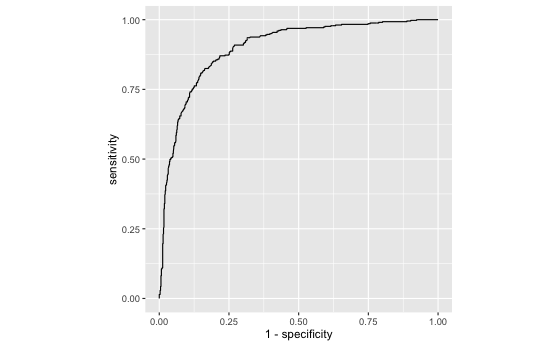

```r
# ROC (receiver operating characteristic curve)
roc_best_model <- orange_juice_with_model_best %>%
  roc(response = purchase_mm, predictor = pred)
# plot ROC (the closer the curve is to the top left corner, the more effective the classifier)
roc_curve <- ggroc(data = roc_best_model, legacy.axes = TRUE) +
  coord_fixed()
roc_curve
```

```r
# AUC (are under curve) gives me an exact number as a measure of performance of my classifier
# the higher AUC the better
AUC <- auc(roc_best_model, )
AUC
```

```
Area under the curve: 0.8995
```

```r
# GINI coefficient (normalised AUC so that a random classifier has value 0, and a perfect classifier has value 1)
GINI <- 2 * AUC - 1
GINI
```

```
[1] 0.7989908
```

## Conclusion:

### I split the data set containing information on sales of orange juice into train and test data sets.

### Using the *train* data set, I developed 10 best logistic regresion models (based on the lowest BIC), containing main effects only.

### Then I also added pair wise interations for variables already assigned as main efects in the models and again listed 10 best models.

### I then applied these models onto the *test* data set and calculated root-mean-square error (RMSE) for each of the models.

### This model came as the best one over all (based on the lowest RMSE = 2.973292):

*ppurchase_mm ~ 1 + price_ch + price_mm + loyal_ch + pct_disc_mm + pct_disc_ch + pct_disc_ch:pct_disc_mm* ### I looked at the model performance - calculated confusion matrix (TP + TN = 888, FP + FN = 182), plotted ROC curve, calculated AUC (= 0.8995) and GINI (= 0.7989908).